```python
import warnings
warnings.filterwarnings('ignore')

import numpy as np
import pandas as pd
from datetime import datetime
from scipy.io import loadmat
from sklearn.decomposition import PCA
from sklearn.model_selection import (train_test_split, GridSearchCV)
from sklearn.metrics import (confusion_matrix, roc_curve, roc_auc_score)
from sklearn.cross_validation import KFold
from sklearn.ensemble import (RandomForestClassifier, AdaBoostClassifier,
                              GradientBoostingClassifier)
from xgboost.sklearn import XGBClassifier

%matplotlib inline
import matplotlib.pyplot as plt
import seaborn as sns
```

```python
start = datetime.now().isoformat()
```

```python
def biplot(setting, pca, x_reduced, y_train):
    pca_score = x_reduced[:,0:2]
    pca_coeff = pca.components_[0:2, :].T

    # Plot setup
    limit = { 'mnist': 0.5, 'mnist_zoomed': 0.15, 'sheep': 0.75 }
    f = plt.figure(figsize=(12, 12))
    plt.xlim(-limit[setting], limit[setting])
    plt.ylim(-limit[setting], limit[setting])
    ax = f.gca()
    radius = { 'mnist': 0.01, 'mnist_zoomed': 0.01, 'sheep': 0.05 }
    for i in range(5, 15, 1):
        rcircle = plt.Circle( (0,0), i * radius[setting], edgecolor="black", facecolor="none", alpha=0.8)
        ax.add_artist(rcircle)
    plt.xlabel("PC1", fontsize=16)
    plt.ylabel("PC2", fontsize=16)
    plt.grid()

    # Draw the data points.
    scatter_alpha = { 'mnist': 0.4, 'mnist_zoomed': 0.3, 'sheep': 0.4 }
    xs = pca_score[:,0]
    ys = pca_score[:,1]
    scalex = 1.0/(xs.max() - xs.min())
    scaley = 1.0/(ys.max() - ys.min())
    plt.scatter(xs * scalex, ys * scaley, c=y_train, s=25, alpha=scatter_alpha[setting])

    # Draw the variable vectors and names.
    var_fontsize = { 'mnist': 8, 'mnist_zoomed': 15, 'sheep': 20 }
    for i in range(p):
        plt.arrow(0, 0, pca_coeff[i,0], pca_coeff[i,1],
                  color = 'black', alpha = 0.5, width=0.0001)
        plt.text(pca_coeff[i,0]* 1.05, pca_coeff[i,1] * 1.05, str(i),
                 color = 'navy', ha = 'center', va = 'center', fontsize=var_fontsize[setting])
    plt.show()

def gridsearchcv_fit(clf, params, x_train, y_train):
    gs = GridSearchCV(clf, params, cv=10, scoring='roc_auc', n_jobs=-1, verbose=1)
    gs.fit(x_train, y_train)
    print("Search found the best params: {}\nROC AUC Train Score: {}"
          .format(gs.best_params_, gs.best_score_))
    return gs.best_estimator_

def precision_recall(cm):
    fp, fn, tp = cm[0][1], cm[1][0], cm[1][1]
    precision = tp / (tp + fp)
    recall = tp / (tp + fn)
    return precision * 100, recall * 100

def plot_roc(y_test, y_score):
    fpr, tpr, th = roc_curve(y_true=y_test, y_score=y_score)
    plt.plot(fpr, tpr, linewidth=2)
    plt.plot([0, 1], [0, 1], 'k--')
    plt.axis([0, 1, 0, 1])
    plt.xlabel('False Positive Rate')
    plt.ylabel('True Positive Rate')

def get_oob(clf, x_train, y_train, x_test, random_state):
    n_folds = 10
    n_train = x_train.shape[0]
    n_test = x_test.shape[0]
    oob_train = np.zeros((n_train,))
    oob_test = np.zeros((n_test,))
    oob_test_skf = np.empty((n_folds, n_test))

    kf = KFold(n_train, n_folds=n_folds, shuffle=True, random_state=random_state)

    for i, (train_index, test_index) in enumerate(kf):
        x_tr = x_train[train_index]
        y_tr = y_train[train_index]
        x_te = x_train[test_index]

        clf.fit(x_tr, y_tr)

        oob_train[test_index] = clf.predict(x_te)
        oob_test_skf[i, :] = clf.predict(x_test)

    oob_test[:] = np.around(oob_test_skf.mean(axis=0))
    return oob_train.reshape(-1, 1), oob_test.reshape(-1, 1)

def barchart_double(min_ylim, max_ylim, n_groups, list1, label1, list2, label2):
    fig, ax = plt.subplots(figsize=(15,5))
    ax.set(ylim=[min_ylim, max_ylim])
    #plt.figure(figsize=(15,5))
    index = np.arange(n_groups)
    bar_width = 0.35
    opacity = 0.8

    rects1 = plt.bar(index, list1, bar_width,
                     alpha=opacity,
                     color='b',
                     label=label1)

    rects2 = plt.bar(index + bar_width, list2, bar_width,
                     alpha=opacity,
                     color='g',
                     label=label2)

    plt.xticks(index + bar_width, ('Random Forest', 'AdaBoost', 'XGBoost', 'Majority Vote', 'Meta-Forest', 'Meta-XGBoost'))
    plt.legend()

    plt.tight_layout()
    plt.show()
```

# Overview

- The main aim of this analysis is to compare the binary classification performance of popular ensembling algorithms and methods: Random Forest, AdaBoost, XGBoost; and two stacking methods: Majority Vote and Meta Learning (Random Forest and XGBoost)
- For a broader picture, the comparison is performed on two datasets.
- The difference between them is that the MNIST response is heavily skewed, where one class vastly outnumbers the other.
- A secondary aim is to observe if any algorithm may perform well on precision or recall while being outperformed by another algorithm overall. It is expected that this may manifest more noticeably on the skewed MNIST data.
- The overall measurement used is the ROC AUC score for a more relevant comparison to the Sheep data where precision/recall is expected to be less relevant.

# MNIST Dataset Preparation

```python
mnist = loadmat('mnist-original.mat')
mnist.keys()
```

```
dict_keys(['data', '__globals__', '__version__', '__header__', 'mldata_descr_ordering', 'label'])
```

```python
data = mnist['data'].T
label = (mnist['label'] == 1).astype(int).T
n, p = data.shape
classes, counts = np.unique(label, return_counts=True)
print("n = {}\np = {}\nclass, count:\n{} ".format(n, p, list(zip(classes, counts))))
```

```
n = 70000
p = 784
class, count:
[(0, 62123), (1, 7877)]
```

As both datasets differ in class counts, they will both be converted to a binary classification problem.  
For this dataset, the label value of 1 denotes the handwritten image is classified as the digit 1, and 0 denotes all digits (0 to 9) excluding 1.

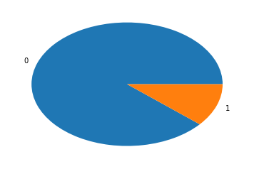

```python
plt.pie(counts, labels=classes)
plt.show()
```

Figure 1: Proportion of classes in the data is heavily skewed which may influence or explain performance differences of the learning methods between this dataset and the sheep dataset (which is later found to be relatively balanced).

## Split data into train/test

```python
seed = 0
x_train_split, x_test_split, y_train, y_test = train_test_split(data, label, train_size=4000, random_state=seed)
y_train, y_test = y_train.ravel(), y_test.ravel()
print("n_train, n_test: {0}, {1}".format(len(y_train), len(y_test)))
```

```
n_train, n_test: 4000, 66000
```

The traditional 80%/20% train/split ratio would push training times too long considering the objectives of this analysis. For both datasets, 4000 instances are allocated for training, and the remaining for testing.

# Correlation Heatmap

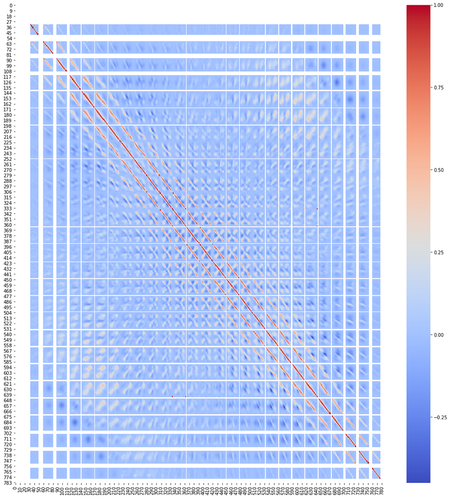

```python
f, ax = plt.subplots(figsize=(18, 18))
corr = pd.DataFrame(x_train_split).corr()
hm = sns.heatmap(round(corr,2), annot=False, ax=ax, cmap="coolwarm",fmt='.2f')
f.subplots_adjust(top=0.93)
```

# Principle Component Analysis

```python
pca_init = PCA(n_components=0.95)
x_reduced1 = pca_init.fit_transform(x_train_split)
print("Number of Dimensions:\n{:3d} - original\n{:3d} - reduced ({} dimensions eliminated)"
      .format(p, x_reduced1.shape[1], p - x_reduced1.shape[1]))
```

```
Number of Dimensions:
784 - original
147 - reduced (637 dimensions eliminated)
```

The PCA is initially run to maximally reduce the number of dimensions while retaining information that explains 95% of the variance. This transformation has eliminated a large majority dimensions, adding to evidence of high correlation and redundant information.

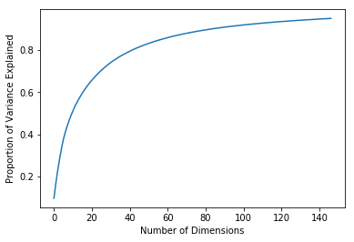

```python
plt.plot(np.cumsum(pca_init.explained_variance_ratio_))
plt.xlabel("Number of Dimensions")
plt.ylabel("Proportion of Variance Explained")
plt.show()
```

Figure 3: The proportion of variance explained plots a smooth curve, i.e. there appears to be no obvious "elbow". A dimension value within the range of 25 and 50 could be argued as a range that appears most "elbow-like".  
The proportion value of 80% lies within this range and is thus chosen to run another PCA to further reduce dimensions and achieve faster training speeds. The plot shows that 15 percentage points of explained variance can be sacrificed for discarding approximately 100 dimensions.

```python
pca_final = PCA(n_components=0.8)
x_reduced2 = pca_final.fit_transform(x_train_split)
print("Number of Dimensions:\n{:3d} - original\n{:3d} - reduced ({} dimensions eliminated)"
      .format(p, x_reduced2.shape[1], p - x_reduced2.shape[1]))
```

```
Number of Dimensions:
784 - original
 43 - reduced (741 dimensions eliminated)
```

A further 100 dimensions are eliminated for a sacrifice of 15% percentage points. Given the context of this analysis and the hardware running these algorithms, it is considered a worthwhile tradeoff to train on this transformation rather than the original 784 dimension data.

## PCA Biplot

```python
pc1evr, pc2evr = np.multiply(pca_final.explained_variance_ratio_[:2], np.full(2, 100))
print("Proportion of Variance Explained:\n{:.2f}% - PC1\n{:.2f}% - PC2\n{:.2f}% - PC1 and PC2"
      .format(pc1evr, pc2evr, pc1evr + pc2evr))
```

```
Proportion of Variance Explained:
9.61% - PC1
7.18% - PC2
16.79% - PC1 and PC2
```

The first 2 components that will be plotted contribute to 16.79% of the variance. Although this is a significant amount in relation to the high dimensions, there will still be a large majority of variance missing from the following plots.

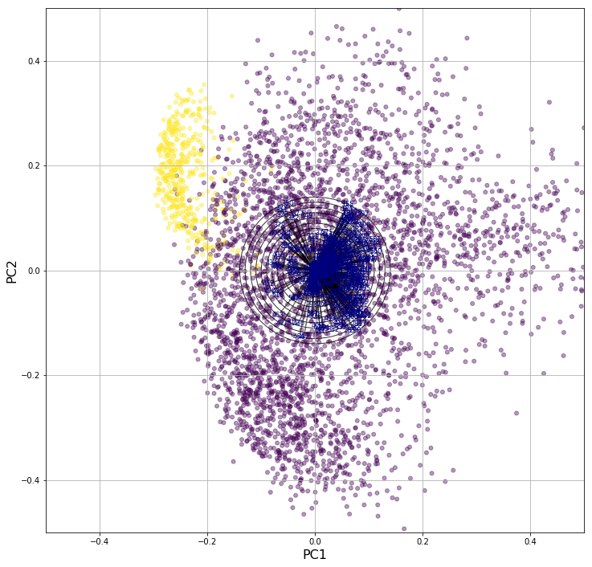

```python
biplot('mnist', pca_final, x_reduced2, y_train)
```

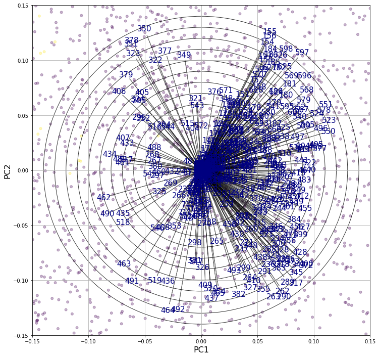

```python
biplot('mnist_zoomed', pca_final, x_reduced2, y_train)
```

# Model Training

- k = 10 folds are used for cross validation to search for the best params.
- The ROC AUC method of scoring is chosen to determine the model with the best params.
- Both the ROC AUC and precision/recall methods of scoring are chosen to record and compare all final models between both datasets.
- Where applicable, the maximum number of available threads for training computation is used.
- For this dataset, the previous pca transformation is applied to reduce the dataset's dimensionality for faster training times.

```python
n_jobs = -1
auc_mnist = {}
pr_mnist = {}
x_train = pca_final.transform(x_train_split)
x_test = pca_final.transform(x_test_split)
x_train.shape, x_test.shape
```

```
((4000, 43), (66000, 43))
```

## Random Forest

```python
p_reduced = x_test.shape[1]
rf_params = [
    {'n_estimators': [ 1500, 1750, 2000, 2250 ], 'max_features': [ "sqrt", int(p_reduced / 3) ]}
]
```

- n_estimators: The number of trees.
- max_features: m = the size of the subset of features considered for each tree. "sqrt" denotes the m = sqrt(p) setting that is mostly recommended for classification, while the next setting, m = p / 3, is recommended for regression.

```python
rf_init = RandomForestClassifier(random_state=seed, n_jobs=n_jobs, verbose=1)
rf = gridsearchcv_fit(rf_init, rf_params, x_train, y_train)
```

```
Fitting 10 folds for each of 8 candidates, totalling 80 fits
```

[output not shown]

[output cut: 1513 more lines]

[output not shown]

```
Search found the best params: {'max_features': 'sqrt', 'n_estimators': 2000}
ROC AUC Train Score: 0.998492175760427
```

```
[Parallel(n_jobs=-1)]: Done 2000 out of 2000 | elapsed:    3.3s finished
```

```python
rf
```

```
RandomForestClassifier(bootstrap=True, class_weight=None, criterion='gini',
            max_depth=None, max_features='sqrt', max_leaf_nodes=None,
            min_impurity_decrease=0.0, min_impurity_split=None,
            min_samples_leaf=1, min_samples_split=2,
            min_weight_fraction_leaf=0.0, n_estimators=2000, n_jobs=-1,
            oob_score=False, random_state=0, verbose=1, warm_start=False)
```

The random forest model according to Breiman involves bootstrapping which is enabled here as default. In this model, the common criterion of the Gini Index is used to determine the split at each tree node. For classification, the recommended setting of "sqrt" for classification is confirmed to be optimal here. With this setting, 2000 trees were found to produce the best ROC before overfitting at 2250 trees.

### Feature Importances

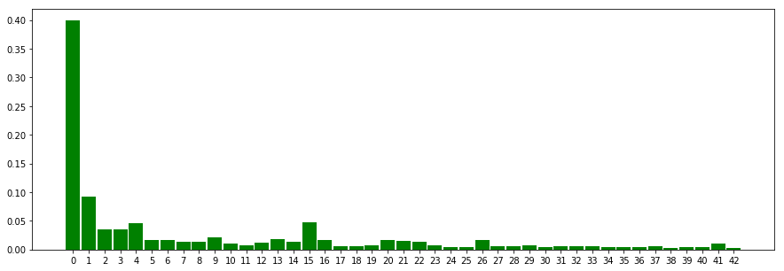

```python
f = plt.figure(figsize=(15,5))
bar_x_axis = range(len(rf.feature_importances_))
plt.bar(bar_x_axis, rf.feature_importances_, width=0.9, color="g", tick_label=bar_x_axis)
plt.tick_params(labelsize=10)
plt.show()
```

Figure 5: Bar chart of the Random Forest's feature importances. Naturally, the Random Forest finds the first few features (i.e. the most useful principal components) to be the most important.

### Prediction Performance

```python
rf_y_pred = rf.predict(x_test)
rf_cm = confusion_matrix(y_true=y_test, y_pred=rf_y_pred)
rf_cm
```

```
[Parallel(n_jobs=8)]: Done  34 tasks      | elapsed:    0.0s
[Parallel(n_jobs=8)]: Done 184 tasks      | elapsed:    0.2s
[Parallel(n_jobs=8)]: Done 434 tasks      | elapsed:    0.4s
[Parallel(n_jobs=8)]: Done 784 tasks      | elapsed:    0.7s
[Parallel(n_jobs=8)]: Done 1234 tasks      | elapsed:    1.1s
[Parallel(n_jobs=8)]: Done 1784 tasks      | elapsed:    1.6s
[Parallel(n_jobs=8)]: Done 2000 out of 2000 | elapsed:    1.8s finished
```

```
array([[58466,    96],
       [  481,  6957]])
```

The Random Forest model has predicted 58466 true negatives and 6957 true positives.

```python
pr_mnist['Random Forest'] = precision_recall(rf_cm)
pr_mnist
```

```
{'Random Forest': (98.6388770735857, 93.53320785157301)}
```

The Random Forest model scored a positive prediction accuracy of 98.64% (precision).  
The rate of positive instances that are correctly detected is 93.533% (recall/sensitivity).  
The model is found to be more precise than sensitive.

```
[Parallel(n_jobs=8)]: Done  34 tasks      | elapsed:    0.0s
[Parallel(n_jobs=8)]: Done 184 tasks      | elapsed:    0.2s
[Parallel(n_jobs=8)]: Done 434 tasks      | elapsed:    0.4s
[Parallel(n_jobs=8)]: Done 784 tasks      | elapsed:    0.7s
[Parallel(n_jobs=8)]: Done 1234 tasks      | elapsed:    1.2s
[Parallel(n_jobs=8)]: Done 1784 tasks      | elapsed:    1.7s
[Parallel(n_jobs=8)]: Done 2000 out of 2000 | elapsed:    1.9s finished
```

```
ROC AUC Test Score: 0.9981555217541017
```

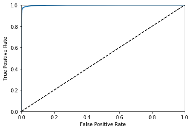

```python
rf_y_score = rf.predict_proba(x_test)[:, 1]
plot_roc(y_test, rf_y_score)
auc_mnist['Random Forest'] = roc_auc_score(y_true=y_test, y_score=rf_y_score)
print("ROC AUC Test Score: {}".format(auc_mnist['Random Forest']))
plt.show()
```

Figure 6: The Random Forest's ROC Curve on the test data.

## AdaBoost

```python
ab_params = [
    {'n_estimators': [ 800, 1000, 1200, 1400 ], 'learning_rate': [ 0.005, 0.01, 0.05, 0.1 ]}
]
```

- n_estimators: The number of trees.
- learning_rate: Applied to the weight of each tree, shrinking its contribution to the model. Lower rates are expected to better detect subtle features while requiring more trees to surprass underfitting. Higher rates risk premature overfitting. Compared to the Random Forest grid search, more combinations are tried to account for this relationship.

```python
ab_init = AdaBoostClassifier(random_state=seed)
ab = gridsearchcv_fit(ab_init, ab_params, x_train, y_train)
```

```
Fitting 10 folds for each of 16 candidates, totalling 160 fits
```

```
[Parallel(n_jobs=-1)]: Done  34 tasks      | elapsed:  2.0min
[Parallel(n_jobs=-1)]: Done 160 out of 160 | elapsed:  8.7min finished
```

```
Search found the best params: {'learning_rate': 0.01, 'n_estimators': 1200}
ROC AUC Train Score: 0.9967975931969577
```

```python
ab
```

```
AdaBoostClassifier(algorithm='SAMME.R', base_estimator=None,
          learning_rate=0.01, n_estimators=1200, random_state=0)
```

The AdaBoost model implemented by SciKit-Learn uses the SAMME.R algorithm by default. This algorithm extends the original AdaBoost algorithm by generalizing from the binary classification problem to multi-class problems. The weak learner used by default is the decision tree that splits using the Gini index.  
The model found the optimal value combination of 1200 trees at a rate of 0.01.

### Feature Importances

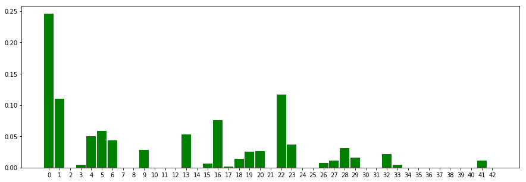

```python
f = plt.figure(figsize=(15,5))
bar_x_axis = range(len(ab.feature_importances_))
plt.bar(bar_x_axis, ab.feature_importances_, width=0.9, color="g", tick_label=bar_x_axis)
plt.tick_params(labelsize=10)
plt.show()
```

Figure 7: Bar chart of AdaBoost's feature importances. Interestingly, the model has considered a few principle components (e.g. 16, 22) to be relatively more important than those features that correspond to principle components that explain more variance.

### Prediction Performance

```python
ab_y_pred = ab.predict(x_test)
ab_cm = confusion_matrix(y_true=y_test, y_pred=ab_y_pred)
ab_cm
```

```
array([[58078,   484],
       [  379,  7059]])
```

The AdaBoost model has predicted 58078 true negatives and 7059 true positives.

```python
pr_mnist['AdaBoost'] = precision_recall(ab_cm)
pr_mnist
```

```
{'AdaBoost': (93.58345485880949, 94.90454423232052),
 'Random Forest': (98.6388770735857, 93.53320785157301)}
```

```
ROC AUC Test Score: 0.9964689831372104
```

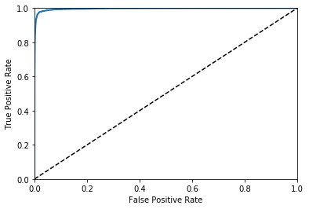

```python
ab_y_score = ab.predict_proba(x_test)[:, 1]
plot_roc(y_test, ab_y_score)
auc_mnist['AdaBoost'] = roc_auc_score(y_true=y_test, y_score=ab_y_score)
print("ROC AUC Test Score: {}".format(auc_mnist['AdaBoost']))
plt.show()
```

Figure 8: AdaBoost's ROC Curve on the test data.

```python
auc_mnist
```

```
{'AdaBoost': 0.9964689831372104, 'Random Forest': 0.9981555217541017}
```

So far, the Random Forest is winning.

## XGBoost

```python
xg_params = [
    {'n_estimators': [ 800, 1000, 1200, 1400 ], 'learning_rate': [ 0.0001, 0.001, 0.01, 0.1 ],
     'max_depth': [ 8, 12, 16 ], 'colsample_bytree': [ np.sqrt(p_reduced) / p_reduced, 1 / 3, 1 ]}
]
```

- n_estimators: The number of trees.
- learning_rate: Same as AdaBoost.
- max_depth: Controls the limit of how many nodes each tree can grow which increases the complexity and flexibility of the model. Theoretically, subtler features should be easier detected with the risk of interpreting noise as information.
- colsample_bytree: This hyperparameter is analogous to Random Forest's max_features and is chosen for adjustment to provide a member to the stacking methods that can be considered a mix between AdaBoost and Random Forest for balanced diversity. Therefore, similar values are chosen for searching (sqrt(p) and p / 3) in addition to the 1 value which corresponds to the subset size being equal to the size of the original set of features. This parameter requires a float and so the values must be normalized.

```python
xg_init = XGBClassifier(random_state=seed)
xg = gridsearchcv_fit(xg_init, xg_params, x_train, y_train)
```

```
Fitting 10 folds for each of 144 candidates, totalling 1440 fits
```

```
[Parallel(n_jobs=-1)]: Done  34 tasks      | elapsed:   25.5s
[Parallel(n_jobs=-1)]: Done 184 tasks      | elapsed:  2.4min
[Parallel(n_jobs=-1)]: Done 434 tasks      | elapsed:  4.9min
[Parallel(n_jobs=-1)]: Done 784 tasks      | elapsed: 11.8min
[Parallel(n_jobs=-1)]: Done 1234 tasks      | elapsed: 30.6min
[Parallel(n_jobs=-1)]: Done 1440 out of 1440 | elapsed: 35.5min finished
```

```
Search found the best params: {'max_depth': 12, 'n_estimators': 1200, 'learning_rate': 0.01, 'colsample_bytree': 0.3333333333333333}
ROC AUC Train Score: 0.998674259961604
```

```python
xg
```

```
XGBClassifier(base_score=0.5, booster='gbtree', colsample_bylevel=1,
       colsample_bytree=0.3333333333333333, gamma=0, learning_rate=0.01,
       max_delta_step=0, max_depth=12, min_child_weight=1, missing=None,
       n_estimators=1200, n_jobs=1, nthread=None,
       objective='binary:logistic', random_state=0, reg_alpha=0,
       reg_lambda=1, scale_pos_weight=1, seed=None, silent=True,
       subsample=1)
```

The XGBoost model was fit using the maker's version of a decision tree. A logistic regression model is used as the cost function that is minimized for error convergence. The search found that the optimal model was tuned with feature subset size m = p / 3, tree depth of 12, learning rate eta = 0.01, with a number of 1200 trees.

### Feature Importances

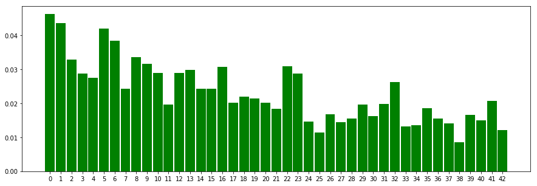

```python
f = plt.figure(figsize=(15,5))
bar_x_axis = range(len(xg.feature_importances_))
plt.bar(bar_x_axis, xg.feature_importances_, width=0.9, color="g", tick_label=bar_x_axis)
plt.tick_params(labelsize=10)
plt.show()
```

Figure 9: Bar chart of XGBoost's feature importances. Compared to the previous models, XGBoost attributes more equal importance among all features.

### Prediction Performance

```python
xg_y_pred = xg.predict(x_test)
xg_cm = confusion_matrix(y_true=y_test, y_pred=xg_y_pred)
xg_cm
```

```
array([[58440,   122],
       [  352,  7086]])
```

The XGBoost model has predicted 58440 true negatives and 7086 true positives.

```python
pr_mnist['XGBoost'] = precision_recall(xg_cm)
pr_mnist
```

```
{'AdaBoost': (93.58345485880949, 94.90454423232052),
 'Random Forest': (98.6388770735857, 93.53320785157301),
 'XGBoost': (98.30743618201998, 95.26754503898897)}
```

The XGBoost model has a positive prediction accuracy of 98.31% (precision).  
The rate of positive instances that are correctly detected is 95.27% (recall/sensitivity). Like Random Forest, it is more precise than sensitive, but the difference is smaller.

```
ROC AUC Test Score: 0.9982809452784596
```

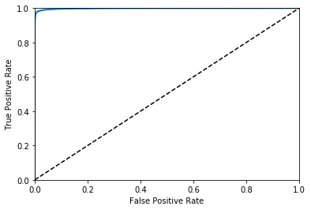

```python
xg_y_score = xg.predict_proba(x_test)[:, 1]
plot_roc(y_test, xg_y_score)
auc_mnist['XGBoost'] = roc_auc_score(y_true=y_test, y_score=xg_y_score)
print("ROC AUC Test Score: {}".format(auc_mnist['XGBoost']))
plt.show()
```

Figure 10: XBoost's ROC Curve on the test data.

```python
auc_mnist
```

```
{'AdaBoost': 0.9964689831372104,
 'Random Forest': 0.9981555217541017,
 'XGBoost': 0.9982809452784596}
```

XGBoost has taken a slight lead overall.

# Model Stacking

```python
rf_oobtrain, rf_oobtest = get_oob(rf, x_train, y_train, x_test, seed)
ab_oobtrain, ab_oobtest = get_oob(ab, x_train, y_train, x_test, seed)
xg_oobtrain, xg_oobtest = get_oob(xg, x_train, y_train, x_test, seed)
print("OoB predictions complete!")
```

[output not shown]

[output cut: 155 more lines]

[output not shown]

```
OoB predictions complete!
```

```python
x_train_meta = np.concatenate((rf_oobtrain, ab_oobtrain, xg_oobtrain), axis=1)
x_test_meta = np.concatenate((rf_oobtest, ab_oobtest, xg_oobtest), axis=1)
print("Meta learner's input data sizes:\nTrain: {}, Test: {}".format(x_train_meta.shape, x_test_meta.shape))
```

```
Meta learner's input data sizes:
Train: (4000, 3), Test: (66000, 3)
```

- Predictions are performed on cross validated test folds to avoid using the test set for prediction.
- This is achieved by first dividing the training set into 10 distinct folds.
- The model is trained on 9 folds, and predictions are made on the remaining fold as well as on the test set.
- This is repeated 9 more times, each time using a different fold to predict on where the other 9 folds are used for training. Each time predictions are also made on the test set.
- The predictions of each fold are gathered to form a single dataset known as the out-of-bag training set (_oobtrain).
- The predictions made on the test set (by 10 versions of the model trained on 9 folds) are merged by taking the mean of all predictions made on each instance resulting in a single dataset known as the out-of-bag test set (_oobtest).
- The out-of-bag training set is fed as the input data for a meta learner stacking model.
- The out-of-bag test set is used for producing the test scores.

## Simple Majority Vote

```python
mv_y_scores = x_test_meta.mean(axis=1).reshape(-1,1)
mv_y_pred = np.around(mv_y_scores)
```

Tallies a simple vote for each instance, a majority of 1's predicts a 1, else a 0 is predicted.  
The scores represent the probability of a 1, e.g. if there are 2 out of 3 votes for a 1 to be predicted, the score is 0.67.

### Prediction Performance

```python
mv_cm = confusion_matrix(y_true=y_test, y_pred=mv_y_pred)
mv_cm
```

```
array([[58435,   127],
       [  400,  7038]])
```

The Majority Vote has predicted 58435 true negatives and 7038 true positives.

```python
pr_mnist['Majority Vote'] = precision_recall(mv_cm)
pr_mnist
```

```
{'AdaBoost': (93.58345485880949, 94.90454423232052),
 'Majority Vote': (98.2274947662247, 94.62221027157838),
 'Random Forest': (98.6388770735857, 93.53320785157301),
 'XGBoost': (98.30743618201998, 95.26754503898897)}
```

The Majority Vote model has a positive prediction accuracy of 98.23% (precision).  
The rate of positive instances that are correctly detected is 94.62% (recall/sensitivity).  
Being that it's nature is to average the other model's predictions, it is no surprise that it has found its way to the middle of the pack in precision and recall.

```
ROC AUC Test Score: 0.9797359353447191
```

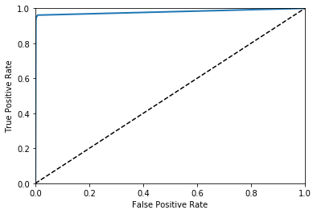

```python
plot_roc(y_test, mv_y_scores)
auc_mnist['Majority Vote'] = roc_auc_score(y_true=y_test, y_score=mv_y_scores)
print("ROC AUC Test Score: {}".format(auc_mnist['Majority Vote']))
plt.show()
```

Figure 11: ROC Curve on the test data from the Majority Vote model.

```python
auc_mnist
```

```
{'AdaBoost': 0.9964689831372104,
 'Majority Vote': 0.9797359353447191,
 'Random Forest': 0.9981555217541017,
 'XGBoost': 0.9982809452784596}
```

The model appears to be overfitting, it has placed last. Treating each of the other model's equally to each other appears to be hampering performance.

## Meta Learner Random Forest

```python
metarf_params = [
    {'n_estimators': [ 10, 20, 50, 100, 200, 400 ]}
]
```

max_features has been tuned to a constant of sqrt(p) considering there are only 3 features. A subset size of 1 feature is assumed to be useless.

```python
metarf_init = RandomForestClassifier(max_features="sqrt", random_state=seed, n_jobs=n_jobs, verbose=1)
metarf = gridsearchcv_fit(metarf_init, metarf_params, x_train_meta, y_train)
```

```
Fitting 10 folds for each of 6 candidates, totalling 60 fits
```

[output not shown]

[output cut: 339 more lines]

[output not shown]

```
Search found the best params: {'n_estimators': 10}
ROC AUC Train Score: 0.9781167061338397
```

```python
metarf
```

```
RandomForestClassifier(bootstrap=True, class_weight=None, criterion='gini',
            max_depth=None, max_features='sqrt', max_leaf_nodes=None,
            min_impurity_decrease=0.0, min_impurity_split=None,
            min_samples_leaf=1, min_samples_split=2,
            min_weight_fraction_leaf=0.0, n_estimators=10, n_jobs=-1,
            oob_score=False, random_state=0, verbose=1, warm_start=False)
```

The search found that overfitting happens fast as the minimum value of 10 trees is chosen to be optimal.

### Prediction Performance

```python
metarf_y_pred = metarf.predict(x_test_meta)
metarf_cm = confusion_matrix(y_true=y_test, y_pred=metarf_y_pred)
metarf_cm
```

```
[Parallel(n_jobs=8)]: Done   6 out of  10 | elapsed:    0.0s remaining:    0.0s
[Parallel(n_jobs=8)]: Done  10 out of  10 | elapsed:    0.0s finished
```

```
array([[58435,   127],
       [  350,  7088]])
```

The Meta Forest model has predicted 58435 true negatives and 7088 true positives.

```python
pr_mnist['Meta-Forest'] = precision_recall(metarf_cm)
pr_mnist
```

```
{'AdaBoost': (93.58345485880949, 94.90454423232052),
 'Majority Vote': (98.2274947662247, 94.62221027157838),
 'Meta-Forest': (98.23977823977825, 95.2944339876311),
 'Random Forest': (98.6388770735857, 93.53320785157301),
 'XGBoost': (98.30743618201998, 95.26754503898897)}
```

The Meta Forest model has a positive prediction accuracy of 98.24% (precision).  
The rate of positive instances that are correctly detected is 95.29% (recall/sensitivity). The Meta Forest slightly outperforms the Majority Vote in precision, while also outperforming the Random Forest in recall.

```
[Parallel(n_jobs=8)]: Done   6 out of  10 | elapsed:    0.0s remaining:    0.0s
[Parallel(n_jobs=8)]: Done  10 out of  10 | elapsed:    0.0s finished
```

```
ROC AUC Test Score: 0.9794651908780632
```

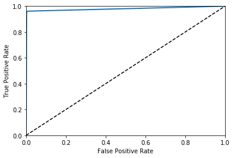

```python
metarf_y_score = metarf.predict_proba(x_test_meta)[:, 1]
plot_roc(y_test, metarf_y_score)
auc_mnist['Meta-Forest'] = roc_auc_score(y_true=y_test, y_score=metarf_y_score)
print("ROC AUC Test Score: {}".format(auc_mnist['Meta-Forest']))
plt.show()
```

Figure 12: ROC Curve on the test data from the Meta Forest.

```python
auc_mnist
```

```
{'AdaBoost': 0.9964689831372104,
 'Majority Vote': 0.9797359353447191,
 'Meta-Forest': 0.9794651908780632,
 'Random Forest': 0.9981555217541017,
 'XGBoost': 0.9982809452784596}
```

Unfortunately, decorrelating the influence of each of the lower layer models doesn't appear to improve overall performance over the Majority Vote model.

## Meta Learner XGBoost

```python
metaxg_params = [
    {'n_estimators': [ 1200, 1400, 1600, 1800 ], 'learning_rate': [ 1e-12, 1e-10, 1e-08, 1e-06 ],
     'max_depth': [ 1, 2 ], 'colsample_bytree': [ 1 / 3, 2 / 3, 1 ] }
]
```

With only 3 features, it is expected that the optimal model might require more trees (and thus slower learning rates) than the non-meta learner model.  
colsample_bytree is considered useful in this model because this algorithm involves weights. That is, even if only one feature is used to split, the overall weight attributed to the resulting tree will provide some assurance of its usefulness.

```python
metaxg_init = XGBClassifier(random_state=seed)
metaxg = gridsearchcv_fit(metaxg_init, metaxg_params, x_train_meta, y_train)
```

```
Fitting 10 folds for each of 96 candidates, totalling 960 fits
```

```
[Parallel(n_jobs=-1)]: Done  34 tasks      | elapsed:    2.4s
[Parallel(n_jobs=-1)]: Done 184 tasks      | elapsed:   13.2s
[Parallel(n_jobs=-1)]: Done 434 tasks      | elapsed:   32.6s
[Parallel(n_jobs=-1)]: Done 784 tasks      | elapsed:  1.0min
[Parallel(n_jobs=-1)]: Done 960 out of 960 | elapsed:  1.3min finished
```

```
Search found the best params: {'max_depth': 1, 'n_estimators': 1800, 'learning_rate': 1e-10, 'colsample_bytree': 0.3333333333333333}
ROC AUC Train Score: 0.9805043465832778
```

```python
metaxg
```

```
XGBClassifier(base_score=0.5, booster='gbtree', colsample_bylevel=1,
       colsample_bytree=0.3333333333333333, gamma=0, learning_rate=1e-10,
       max_delta_step=0, max_depth=1, min_child_weight=1, missing=None,
       n_estimators=1800, n_jobs=1, nthread=None,
       objective='binary:logistic', random_state=0, reg_alpha=0,
       reg_lambda=1, scale_pos_weight=1, seed=None, silent=True,
       subsample=1)
```

The search found that restricting flexibility to the additive model (max_depth = 1) prevented overfitting.  
Unexpectedly, the model that subsetted the feature space to 0.3 = 1 feature was found to be the best.  
The maximum number of 1800 trees at a learning rate of 1e-10 was found which gives reason to re-run the search with higher values. However, it was noticed that increasing further did not decrease performance.

### Prediction Performance

```python
metaxg_y_pred = metaxg.predict(x_test_meta)
metaxg_cm = confusion_matrix(y_true=y_test, y_pred=metaxg_y_pred)
metaxg_cm
```

```
array([[58435,   127],
       [  400,  7038]])
```

The Meta XGBoost model has predicted 58435 true negatives and 7038 true positives. This is identical to the Majority Vote matrix.

```python
pr_mnist['Meta-XGBoost'] = precision_recall(metaxg_cm)
pr_mnist
```

```
{'AdaBoost': (93.58345485880949, 94.90454423232052),
 'Majority Vote': (98.2274947662247, 94.62221027157838),
 'Meta-Forest': (98.23977823977825, 95.2944339876311),
 'Meta-XGBoost': (98.2274947662247, 94.62221027157838),
 'Random Forest': (98.6388770735857, 93.53320785157301),
 'XGBoost': (98.30743618201998, 95.26754503898897)}
```

The Meta XGBoost model has a positive prediction accuracy of 98.23% (precision).  
The rate of positive instances that are correctly detected is 94.62% (recall/sensitivity). As mentioned, this is identical to the Majority Vote results.

```
ROC AUC Test Score: 0.9797359353447191
```

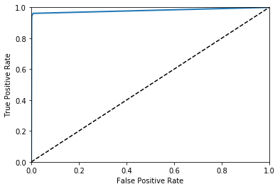

```python
metaxg_y_score = metaxg.predict_proba(x_test_meta)[:, 1]
plot_roc(y_test, metaxg_y_score)
auc_mnist['Meta-XGBoost'] = roc_auc_score(y_true=y_test, y_score=metaxg_y_score)
print("ROC AUC Test Score: {}".format(auc_mnist['Meta-XGBoost']))
plt.show()
```

Figure 13: ROC Curve on the test data from the Meta XGBoost.

```python
auc_mnist
```

```
{'AdaBoost': 0.9964689831372104,
 'Majority Vote': 0.9797359353447191,
 'Meta-Forest': 0.9794651908780632,
 'Meta-XGBoost': 0.9797359353447191,
 'Random Forest': 0.9981555217541017,
 'XGBoost': 0.9982809452784596}
```

Perhaps this model has learned that the best stacking model on this dataset is the Majority Vote.  
Overall, the stacking models appear to be beat by the non-stacking models. This is a similar result to the performance of non-linear models compared to linear model when the data is linear. Essentially, these models are trained to identify an image of a straight line (a handwritten number 1), so it could be reasonably argued that models with less flexibility are expected to perform better. The next dataset should provide additional perspective, as its underlying function is expected to be complex and non-linear.

# Sheep Dataset Preparation

```python
sheep = loadmat('sheep_10s_ws/sheep_10s_ws.mat')
sheep.keys()
```

```
dict_keys(['Ps2feature10s', 'sheep16th10sfeature', '__version__', '__header__', 'Ys2feature10s', 'Gs2feature10s', '__globals__'])
```

The Sheep data set is collection of 4 data sets, 1 for each sheep and then one that contains all others. The latter is the one used for this analysis. Each instance represents a 10 second window of measurements collected from accelorometers attached to sheep that senses its movement. The movement is then classified as either walking, standing or grazing. These classes are converted for the binary classification models where 1 represents grazing, and 0 represents not grazing (walking or standing).

```python
dataset = sheep['sheep16th10sfeature']
dataset.shape
```

```
(5176, 56)
```

```python
data = dataset[:,:-1]
label = (dataset[:,-1] == 3).astype(int)
n, p = data.shape
classes, counts = np.unique(label, return_counts=True)
print("n = {}\np = {}\nclass, count:\n{} ".format(n, p, list(zip(classes, counts))))
```

```
n = 5176
p = 55
class, count:
[(0, 1815), (1, 3361)]
```

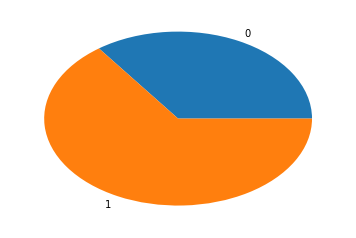

```python
plt.pie(counts, labels=classes)
plt.show()
```

Figure 14: Proportion of classes in this dataset is relatively balanced compared to the MNIST dataset.

## Split data into train/test

```python
x_train, x_test, y_train, y_test = train_test_split(data, label, train_size=4000, random_state=seed)
y_train, y_test = y_train.ravel(), y_test.ravel()
print("n_train, n_test: {0}, {1}".format(len(y_train), len(y_test)))
```

```
n_train, n_test: 4000, 1176
```

The training size used is equal to that of the previous dataset and so the test set is far smaller.

# Correlation Heatmap

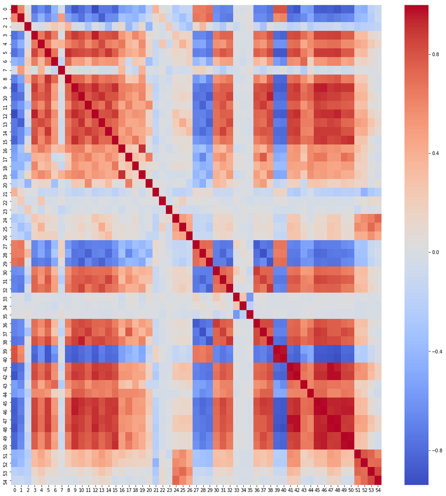

```python
f, ax = plt.subplots(figsize=(18, 18))
corr = pd.DataFrame(x_train).corr()
hm = sns.heatmap(round(corr,2), annot=False, ax=ax, cmap="coolwarm",fmt='.2f')
f.subplots_adjust(top=0.93)
```

Figure 15: Like the MNIST heatmap, this correlation heatmap of the features also reveals a pattern. In this case, multiple groups of adjacent features can be seen as highly correlated manifesting as approximately 8-10 square-shaped groups of red or blue squares. This reflects the ordering of the features during data collection as accelerometers consist of multiple dimensions to capture spatial data. Further, the heavier degrees of correlation are much more frequent in this case. Apart from a few exceptions (features 20-26, 33-35 and 51-54), almost all features show high correlation with almost all other features. This suggests that the Random Forest should outperform the boosting models.

# Principle Component Analysis

```python
pca_init = PCA(n_components=0.95)
x_reduced1 = pca_init.fit_transform(x_train)
print("Number of Dimensions:\n{0:3d} - original\n{1:3d} - reduced ({2} dimensions eliminated)"
      .format(p, x_reduced1.shape[1], p - x_reduced1.shape[1]))
```

```
Number of Dimensions:
 55 - original
  5 - reduced (50 dimensions eliminated)
```

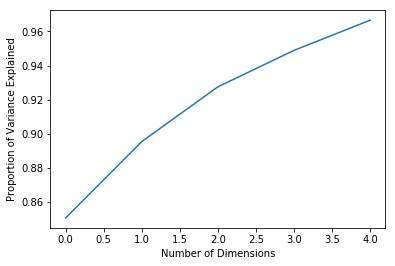

```python
plt.plot(np.cumsum(pca_init.explained_variance_ratio_))
plt.xlabel("Number of Dimensions")
plt.ylabel("Proportion of Variance Explained")
plt.show()
```

Figure 16: Proportion of variance explained plot shows an elbow at 2 dimensions.

## PCA Biplot

```python
pca_final = PCA(n_components=2)
x_reduced2 = pca_final.fit_transform(x_train)
pc1evr, pc2evr = np.multiply(pca_final.explained_variance_ratio_[:2], np.full(2, 100))
print("Proportion of Variance Explained:\n{:.2f}% - PC1\n{:.2f}% - PC2\n{:.2f}% - PC1 and PC2"
      .format(pc1evr, pc2evr, pc1evr + pc2evr))
```

```
Proportion of Variance Explained:
85.06% - PC1
4.48% - PC2
89.54% - PC1 and PC2
```

Another PCA is fit for 2 dimensions before producing the biplot.

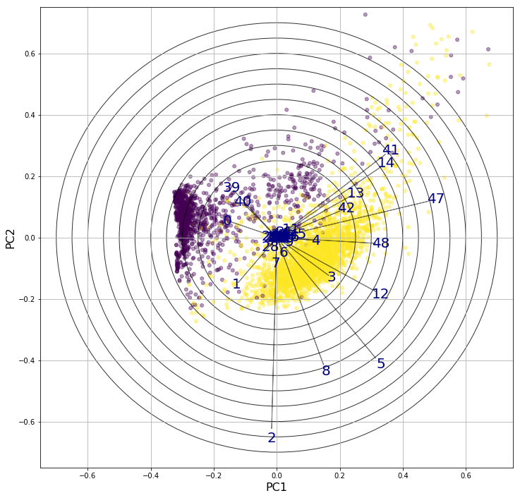

```python
biplot('sheep', pca_final, x_reduced2, y_train)
```

Figure 17: Biplot of all of the two principle components in the final PCA transform. The depicted components account for 89.54% of the variance. Approximately 8-10 vectors appear to have far greater magnitudes than all others, further reflecting the highly correlated nature of the data. The directions of these vectors tend to similar directions, ranging from top right to bottom. The scatter of the data points projected on these dimensions reveals the two classes can be roughly clustered. The alpha density of their colours shows that the clusters centres are well separated. Given these characteristics, the ensembling methods that involve feature decorrelation are expected to outperform others in binary classification.

# Model Training

```python
auc_sheep = {}
pr_sheep = {}
```

## Random Forest

```python
rf_params = [
    {'n_estimators': [ 1500, 1750, 2000, 2250 ], 'max_features': [ "sqrt", int(p / 3) ]}
]
```

```python
rf_init = RandomForestClassifier(random_state=seed, n_jobs=n_jobs, verbose=1)
rf = gridsearchcv_fit(rf_init, rf_params, x_train, y_train)
```

```
Fitting 10 folds for each of 8 candidates, totalling 80 fits
```

[output not shown]

[output cut: 1513 more lines]

[output not shown]

```
Search found the best params: {'max_features': 'sqrt', 'n_estimators': 2000}
ROC AUC Train Score: 0.9953199365649816
```

```
[Parallel(n_jobs=-1)]: Done 2000 out of 2000 | elapsed:    4.8s finished
```

```python
rf
```

```
RandomForestClassifier(bootstrap=True, class_weight=None, criterion='gini',
            max_depth=None, max_features='sqrt', max_leaf_nodes=None,
            min_impurity_decrease=0.0, min_impurity_split=None,
            min_samples_leaf=1, min_samples_split=2,
            min_weight_fraction_leaf=0.0, n_estimators=2000, n_jobs=-1,
            oob_score=False, random_state=0, verbose=1, warm_start=False)
```

The grid search on this dataset returns the Random Forest model with the same hyperparameter settings as the previous dataset: 2000 trees with subset size m = sqrt(p) = 7.

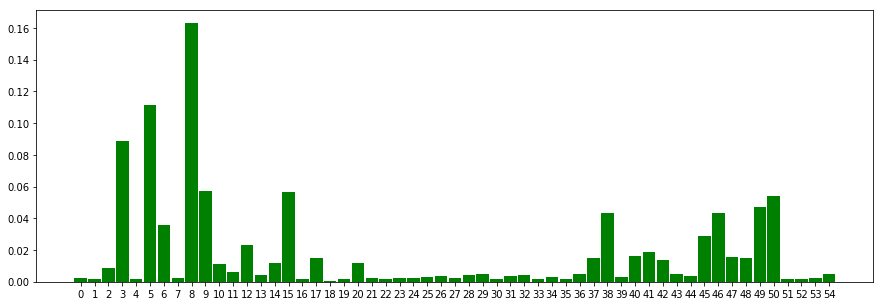

```python
f = plt.figure(figsize=(15,5))
bar_x_axis = range(len(rf.feature_importances_))
plt.bar(bar_x_axis, rf.feature_importances_, width=0.9, color="g", tick_label=bar_x_axis)
plt.tick_params(labelsize=10)
plt.show()
```

Figure 18: Bar chart of the Random Forest's feature importances agrees with the heatmap and the biplot in that there appears to be 8-10 features that it considers important in explaining most of the information.

### Prediction Performance

```python
rf_y_pred = rf.predict(x_test)
rf_cm = confusion_matrix(y_true=y_test, y_pred=rf_y_pred)
rf_cm
```

```
[Parallel(n_jobs=8)]: Done  34 tasks      | elapsed:    0.0s
[Parallel(n_jobs=8)]: Done 184 tasks      | elapsed:    0.0s
[Parallel(n_jobs=8)]: Done 434 tasks      | elapsed:    0.1s
[Parallel(n_jobs=8)]: Done 784 tasks      | elapsed:    0.1s
[Parallel(n_jobs=8)]: Done 1234 tasks      | elapsed:    0.2s
[Parallel(n_jobs=8)]: Done 1784 tasks      | elapsed:    0.3s
[Parallel(n_jobs=8)]: Done 2000 out of 2000 | elapsed:    0.3s finished
```

```
array([[372,  14],
       [ 12, 778]])
```

The Random Forest model has predicted 372 true negatives and 778 true positives.

```python
pr_sheep['Random Forest'] = precision_recall(rf_cm)
pr_sheep
```

```
{'Random Forest': (98.23232323232324, 98.48101265822785)}
```

The Random Forest model scored a positive prediction accuracy of 98.23% (precision).  
The rate of positive instances that are correctly detected is 98.48% (recall/sensitivity). The difference is small as the classes aren't heavily skewed. The precision/recall is expected to be less useful for this dataset.

```
[Parallel(n_jobs=8)]: Done  34 tasks      | elapsed:    0.0s
[Parallel(n_jobs=8)]: Done 184 tasks      | elapsed:    0.0s
[Parallel(n_jobs=8)]: Done 434 tasks      | elapsed:    0.1s
[Parallel(n_jobs=8)]: Done 784 tasks      | elapsed:    0.1s
[Parallel(n_jobs=8)]: Done 1234 tasks      | elapsed:    0.2s
[Parallel(n_jobs=8)]: Done 1784 tasks      | elapsed:    0.3s
[Parallel(n_jobs=8)]: Done 2000 out of 2000 | elapsed:    0.3s finished
```

```
ROC AUC Test Score: 0.9934347740539122
```

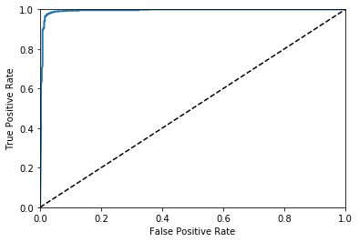

```python
rf_y_score = rf.predict_proba(x_test)[:, 1]
plot_roc(y_test, rf_y_score)
auc_sheep['Random Forest'] = roc_auc_score(y_true=y_test, y_score=rf_y_score)
print("ROC AUC Test Score: {}".format(auc_sheep['Random Forest']))
plt.show()
```

Figure 19: The Random Forest's ROC Curve on the test data.

## AdaBoost

```python
ab_params = [
    {'n_estimators': [ 800, 1000, 1200, 1400 ], 'learning_rate': [ 0.005, 0.01, 0.05, 0.1 ]}
]
```

```python
ab_init = AdaBoostClassifier(random_state=seed)
ab = gridsearchcv_fit(ab_init, ab_params, x_train, y_train)
```

```
Fitting 10 folds for each of 16 candidates, totalling 160 fits
```

```
[Parallel(n_jobs=-1)]: Done  34 tasks      | elapsed:  2.2min
[Parallel(n_jobs=-1)]: Done 160 out of 160 | elapsed:  9.9min finished
```

```
Search found the best params: {'learning_rate': 0.05, 'n_estimators': 1200}
ROC AUC Train Score: 0.9940205520042044
```

```python
ab
```

```
AdaBoostClassifier(algorithm='SAMME.R', base_estimator=None,
          learning_rate=0.05, n_estimators=1200, random_state=0)
```

This search found the same number as in the MNIST dataset of 1200 trees to be optimal. The learning rate was slightly faster at 0.05 (compared to 0.01) to find optimal performance.

### Feature Importances

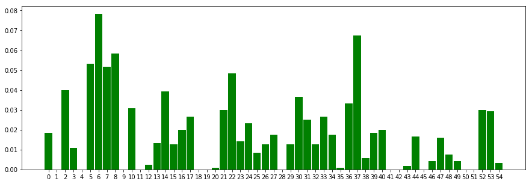

```python
f = plt.figure(figsize=(15,5))
bar_x_axis = range(len(ab.feature_importances_))
plt.bar(bar_x_axis, ab.feature_importances_, width=0.9, color="g", tick_label=bar_x_axis)
plt.tick_params(labelsize=10)
plt.show()
```

Figure 20: Bar chart of AdaBoost's feature importances. Like the previous dataset, AdaBoost attributes a few a more features with higher importance.

### Prediction Performance

```python
ab_y_pred = ab.predict(x_test)
ab_cm = confusion_matrix(y_true=y_test, y_pred=ab_y_pred)
ab_cm
```

```
array([[365,  21],
       [ 13, 777]])
```

The AdaBoost model has predicted 365 true negatives and 777 true positives.

```python
pr_sheep['AdaBoost'] = precision_recall(ab_cm)
pr_sheep
```

```
{'AdaBoost': (97.36842105263158, 98.35443037974684),
 'Random Forest': (98.23232323232324, 98.48101265822785)}
```

The AdaBoost model has a positive prediction accuracy of 97.37% (precision).  
The rate of positive instances that are correctly detected is 98.35% (recall/sensitivity).

```
ROC AUC Test Score: 0.9914802912048272
```

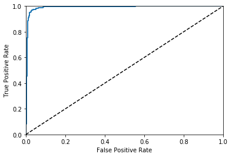

```python
ab_y_score = ab.predict_proba(x_test)[:, 1]
plot_roc(y_test, ab_y_score)
auc_sheep['AdaBoost'] = roc_auc_score(y_true=y_test, y_score=ab_y_score)
print("ROC AUC Test Score: {}".format(auc_sheep['AdaBoost']))
plt.show()
```

Figure 21: AdaBoost's ROC Curve on the test data.

```python
auc_sheep
```

```
{'AdaBoost': 0.9914802912048272, 'Random Forest': 0.9934347740539122}
```

Like the previous dataset, Random Forest comes out on top, almost with the same difference.

## XGBoost

```python
xg_params = [
    {'n_estimators': [ 1600, 1800, 2000, 2200 ], 'learning_rate': [ 0.0001, 0.001, 0.01, 0.1 ],
     'max_depth': [ 8, 12, 16 ], 'colsample_bytree': [ np.sqrt(p_reduced) / p_reduced, 1 / 3, 1 ]}
]
```

```python
xg_init = XGBClassifier(random_state=seed)
xg = gridsearchcv_fit(xg_init, xg_params, x_train, y_train)
```

```
Fitting 10 folds for each of 144 candidates, totalling 1440 fits
```

```
[Parallel(n_jobs=-1)]: Done  34 tasks      | elapsed:   58.1s
[Parallel(n_jobs=-1)]: Done 184 tasks      | elapsed:  5.0min
[Parallel(n_jobs=-1)]: Done 434 tasks      | elapsed: 10.0min
[Parallel(n_jobs=-1)]: Done 784 tasks      | elapsed: 26.3min
[Parallel(n_jobs=-1)]: Done 1234 tasks      | elapsed: 72.1min
[Parallel(n_jobs=-1)]: Done 1440 out of 1440 | elapsed: 85.2min finished
```

```
Search found the best params: {'max_depth': 12, 'n_estimators': 2000, 'learning_rate': 0.001, 'colsample_bytree': 0.3333333333333333}
ROC AUC Train Score: 0.995364844382323
```

```python
xg
```

```
XGBClassifier(base_score=0.5, booster='gbtree', colsample_bylevel=1,
       colsample_bytree=0.3333333333333333, gamma=0, learning_rate=0.001,
       max_delta_step=0, max_depth=12, min_child_weight=1, missing=None,
       n_estimators=2000, n_jobs=1, nthread=None,
       objective='binary:logistic', random_state=0, reg_alpha=0,
       reg_lambda=1, scale_pos_weight=1, seed=None, silent=True,
       subsample=1)
```

This time, the dataset permitted a much higher number of trees (2000 compared to the 1200 in MNIST) before exhibiting signs of overfitting. To settle on the optimal model, a slower learning rate was selected. Similar to the MNIST dataset, injecting random decorrelation via colsample_bytree set to 0.33 was found to be significantly useful. Also, the trees used were adjusted to be highly complex.

### Feature Importances

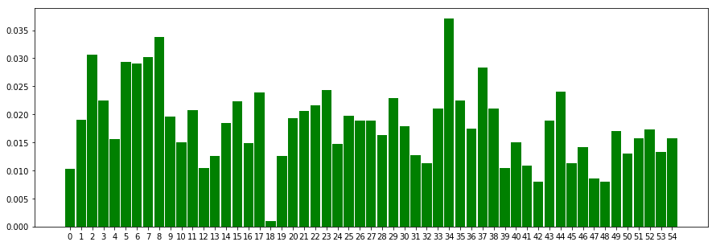

```python
f = plt.figure(figsize=(15,5))
bar_x_axis = range(len(xg.feature_importances_))
plt.bar(bar_x_axis, xg.feature_importances_, width=0.9, color="g", tick_label=bar_x_axis)
plt.tick_params(labelsize=10)
plt.show()
```

Figure 22: Bar chart of XGBoost's feature importances. Like in the previous dataset, XGBoost distributes the importances more evenly.

### Prediction Performance

```python
xg_y_pred = xg.predict(x_test)
xg_cm = confusion_matrix(y_true=y_test, y_pred=xg_y_pred)
xg_cm
```

```
array([[370,  16],
       [ 13, 777]])
```

The XGBoost model has predicted 370 true negatives and 777 true positives.

```python
pr_sheep['XGBoost'] = precision_recall(xg_cm)
pr_sheep
```

```
{'AdaBoost': (97.36842105263158, 98.35443037974684),
 'Random Forest': (98.23232323232324, 98.48101265822785),
 'XGBoost': (97.98234552332913, 98.35443037974684)}
```

The XGBoost model has a positive prediction accuracy of 97.98% (precision).  
The rate of positive instances that are correctly detected is 98.35% (recall/sensitivity).

```
ROC AUC Test Score: 0.9932232570341706
```

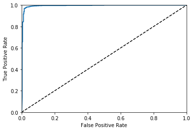

```python
xg_y_score = xg.predict_proba(x_test)[:, 1]
plot_roc(y_test, xg_y_score)
auc_sheep['XGBoost'] = roc_auc_score(y_true=y_test, y_score=xg_y_score)
print("ROC AUC Test Score: {}".format(auc_sheep['XGBoost']))
plt.show()
```

Figure 23: XBoost's ROC Curve on the test data.

```python
auc_sheep
```

```
{'AdaBoost': 0.9914802912048272,
 'Random Forest': 0.9934347740539122,
 'XGBoost': 0.9932232570341706}
```

This time, the Random Forest model remains on top (whereas the XGBoost was best in the MNIST dataset).

# Model Stacking

## Meta Learner Data Preparation

```python
rf_oobtrain, rf_oobtest = get_oob(rf, x_train, y_train, x_test, seed)
ab_oobtrain, ab_oobtest = get_oob(ab, x_train, y_train, x_test, seed)
xg_oobtrain, xg_oobtest = get_oob(xg, x_train, y_train, x_test, seed)
print("OoB predictions complete!")
```

[output not shown]

[output cut: 155 more lines]

[output not shown]

```
OoB predictions complete!
```

```python
x_train_meta = np.concatenate((rf_oobtrain, ab_oobtrain, xg_oobtrain), axis=1)
x_test_meta = np.concatenate((rf_oobtest, ab_oobtest, xg_oobtest), axis=1)
print("Meta learner's input data sizes:\nTrain: {}, Test: {}".format(x_train_meta.shape, x_test_meta.shape))
```

```
Meta learner's input data sizes:
Train: (4000, 3), Test: (1176, 3)
```

## Simple Majority Vote

```python
mv_y_scores = x_test_meta.mean(axis=1).reshape(-1,1)
mv_y_pred = np.around(mv_y_scores)
```

### Prediction Performance

```python
mv_cm = confusion_matrix(y_true=y_test, y_pred=mv_y_pred)
mv_cm
```

```
array([[371,  15],
       [ 12, 778]])
```

The Majority Vote model has predicted 371 true negatives and 778 true positives.

```python
pr_sheep['Majority Vote'] = precision_recall(mv_cm)
pr_sheep
```

```
{'AdaBoost': (97.36842105263158, 98.35443037974684),
 'Majority Vote': (98.10844892812106, 98.48101265822785),
 'Random Forest': (98.23232323232324, 98.48101265822785),
 'XGBoost': (97.98234552332913, 98.35443037974684)}
```

The Majority Vote model has a positive prediction accuracy of 98.11% (precision).  
The rate of positive instances that are correctly detected is 98.48% (recall/sensitivity).

```
ROC AUC Test Score: 0.9789548763691218
```

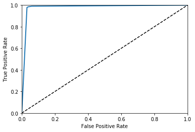

```python
plot_roc(y_test, mv_y_scores)
auc_sheep['Majority Vote'] = roc_auc_score(y_true=y_test, y_score=mv_y_scores)
print("ROC AUC Test Score: {}".format(auc_sheep['Majority Vote']))
plt.show()
```

Figure 24: ROC Curve on the test data from the Majority Vote model.

```python
auc_sheep
```

```
{'AdaBoost': 0.9914802912048272,
 'Majority Vote': 0.9789548763691218,
 'Random Forest': 0.9934347740539122,
 'XGBoost': 0.9932232570341706}
```

Like in the previous dataset, Majority Vote performs markedly worse than the others.

## Meta Learner Random Forest

```python
metarf_params = [
    {'n_estimators': [ 10, 20, 50, 100, 200, 400 ]}
]
```

```python
metarf_init = RandomForestClassifier(max_features="sqrt", random_state=seed, n_jobs=n_jobs, verbose=1)
metarf = gridsearchcv_fit(metarf_init, metarf_params, x_train_meta, y_train)
```

```
Fitting 10 folds for each of 6 candidates, totalling 60 fits
```

[output not shown]

[output cut: 336 more lines]

[output not shown]

```
Search found the best params: {'n_estimators': 20}
ROC AUC Train Score: 0.9762698470332026
```

```
[Parallel(n_jobs=-1)]: Done  60 out of  60 | elapsed:    5.0s finished
[Parallel(n_jobs=-1)]: Done  20 out of  20 | elapsed:    0.0s finished
```

```python
metarf
```

```
RandomForestClassifier(bootstrap=True, class_weight=None, criterion='gini',
            max_depth=None, max_features='sqrt', max_leaf_nodes=None,
            min_impurity_decrease=0.0, min_impurity_split=None,
            min_samples_leaf=1, min_samples_split=2,
            min_weight_fraction_leaf=0.0, n_estimators=20, n_jobs=-1,
            oob_score=False, random_state=0, verbose=1, warm_start=False)
```

This time, the Meta-Forest grew slightly larger to 20 trees before overfitting.

### Prediction Performance

```python
metarf_y_pred = metarf.predict(x_test_meta)
metarf_cm = confusion_matrix(y_true=y_test, y_pred=metarf_y_pred)
metarf_cm
```

```
[Parallel(n_jobs=8)]: Done  20 out of  20 | elapsed:    0.0s finished
```

```
array([[373,  13],
       [ 13, 777]])
```

The Meta-Forest model has predicted 373 true negatives and 777 true positives.

```python
pr_sheep['Meta-Forest'] = precision_recall(metarf_cm)
pr_sheep
```

```
{'AdaBoost': (97.36842105263158, 98.35443037974684),
 'Majority Vote': (98.10844892812106, 98.48101265822785),
 'Meta-Forest': (98.35443037974684, 98.35443037974684),
 'Random Forest': (98.23232323232324, 98.48101265822785),
 'XGBoost': (97.98234552332913, 98.35443037974684)}
```

The Meta-Forest model has a positive prediction accuracy of 98.35% (precision).  
The rate of positive instances that are correctly detected is 98.35% (recall/sensitivity).

```
[Parallel(n_jobs=8)]: Done  20 out of  20 | elapsed:    0.0s finished
```

```
ROC AUC Test Score: 0.9789515970354824
```

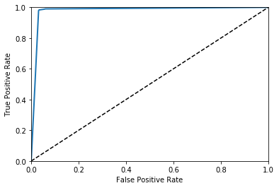

```python
metarf_y_score = metarf.predict_proba(x_test_meta)[:, 1]
plot_roc(y_test, metarf_y_score)
auc_sheep['Meta-Forest'] = roc_auc_score(y_true=y_test, y_score=metarf_y_score)
print("ROC AUC Test Score: {}".format(auc_sheep['Meta-Forest']))
plt.show()
```

Figure 25: ROC Curve on the test data from the Meta-Forest.

```python
auc_sheep
```

```
{'AdaBoost': 0.9914802912048272,
 'Majority Vote': 0.9789548763691218,
 'Meta-Forest': 0.9789515970354824,
 'Random Forest': 0.9934347740539122,
 'XGBoost': 0.9932232570341706}
```

## Meta Learner XGBoost

```python
metaxg_params = [
    {'n_estimators': [ 800, 1000, 1200, 1400, 1400 ], 'learning_rate': [ 1e-12, 1e-10, 1e-08, 1e-06 ],
     'max_depth': [ 1, 2, 4 ], 'colsample_bytree': [ 1 / 3, 2 / 3, 1 ] }
]
```

```python
metaxg_init = XGBClassifier(random_state=seed)
metaxg = gridsearchcv_fit(metaxg_init, metaxg_params, x_train_meta, y_train)
```

```
Fitting 10 folds for each of 180 candidates, totalling 1800 fits
```

```
[Parallel(n_jobs=-1)]: Done  34 tasks      | elapsed:    2.3s
[Parallel(n_jobs=-1)]: Done 184 tasks      | elapsed:   12.3s
[Parallel(n_jobs=-1)]: Done 434 tasks      | elapsed:   30.1s
[Parallel(n_jobs=-1)]: Done 784 tasks      | elapsed:   57.6s
[Parallel(n_jobs=-1)]: Done 1234 tasks      | elapsed:  1.6min
[Parallel(n_jobs=-1)]: Done 1784 tasks      | elapsed:  2.6min
[Parallel(n_jobs=-1)]: Done 1800 out of 1800 | elapsed:  2.7min finished
```

```
Search found the best params: {'max_depth': 2, 'n_estimators': 1000, 'learning_rate': 1e-08, 'colsample_bytree': 0.6666666666666666}
ROC AUC Train Score: 0.9762644087748122
```

```python
metaxg
```

```
XGBClassifier(base_score=0.5, booster='gbtree', colsample_bylevel=1,
       colsample_bytree=0.6666666666666666, gamma=0, learning_rate=1e-08,
       max_delta_step=0, max_depth=2, min_child_weight=1, missing=None,
       n_estimators=1000, n_jobs=1, nthread=None,
       objective='binary:logistic', random_state=0, reg_alpha=0,
       reg_lambda=1, scale_pos_weight=1, seed=None, silent=True,
       subsample=1)
```

This time, the Meta-XGBoost learner found benefit in sampling twice as many features per tree fit. Further, overfitting was encountered sooner, restraining growth to 1000 trees (compared to 1800+ trees in the previous dataset).

### Prediction Performance

```python
metaxg_y_pred = metaxg.predict(x_test_meta)
metaxg_cm = confusion_matrix(y_true=y_test, y_pred=metaxg_y_pred)
metaxg_cm
```

```
array([[371,  15],
       [ 12, 778]])
```

The Meta-XGBoost model has predicted 371 true negatives and 778 true positives.

```python
pr_sheep['Meta-XGBoost'] = precision_recall(metaxg_cm)
pr_sheep
```

```
{'AdaBoost': (97.36842105263158, 98.35443037974684),
 'Majority Vote': (98.10844892812106, 98.48101265822785),
 'Meta-Forest': (98.35443037974684, 98.35443037974684),
 'Meta-XGBoost': (98.10844892812106, 98.48101265822785),
 'Random Forest': (98.23232323232324, 98.48101265822785),
 'XGBoost': (97.98234552332913, 98.35443037974684)}
```

The Meta XGBoost model has a positive prediction accuracy of 98.11% (precision).  
The rate of positive instances that are correctly detected is 98.48% (recall/sensitivity).

```
ROC AUC Test Score: 0.97896471437004
```

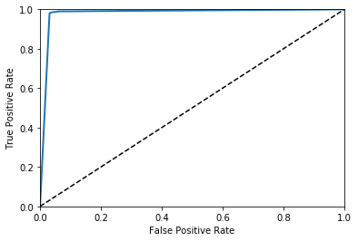

```python
metaxg_y_score = metaxg.predict_proba(x_test_meta)[:, 1]
plot_roc(y_test, metaxg_y_score)
auc_sheep['Meta-XGBoost'] = roc_auc_score(y_true=y_test, y_score=metaxg_y_score)
print("ROC AUC Test Score: {}".format(auc_sheep['Meta-XGBoost']))
plt.show()
```

Figure 26: ROC Curve on the test data from the Meta Learner.

```python
auc_sheep
```

```
{'AdaBoost': 0.9914802912048272,
 'Majority Vote': 0.9789548763691218,
 'Meta-Forest': 0.9789515970354824,
 'Meta-XGBoost': 0.97896471437004,
 'Random Forest': 0.9934347740539122,
 'XGBoost': 0.9932232570341706}
```

```python
auc_sheep = {'AdaBoost': 0.9914802912048272,
 'Majority Vote': 0.9789548763691218,
 'Meta-Forest': 0.9789515970354824,
 'Meta-XGBoost': 0.97896471437004,
 'Random Forest': 0.9934347740539122,
 'XGBoost': 0.9932232570341706}
```

```python
auc_mnist = {'AdaBoost': 0.9964689831372104,
 'Majority Vote': 0.9797359353447191,
 'Meta-Forest': 0.9794651908780632,
 'Meta-XGBoost': 0.9797359353447191,
 'Random Forest': 0.9981555217541017,
 'XGBoost': 0.9982809452784596}
```

# Final Plots and Comments

```python
n_groups = len(auc_mnist)

list_mnist = list(range(n_groups))
list_mnist[0] = auc_mnist['Random Forest']
list_mnist[1] = auc_mnist['AdaBoost']
list_mnist[2] = auc_mnist['XGBoost']
list_mnist[3] = auc_mnist['Majority Vote']
list_mnist[4] = auc_mnist['Meta-Forest']
list_mnist[5] = auc_mnist['Meta-XGBoost']

list_sheep = list(range(n_groups))
list_sheep[0] = auc_sheep['Random Forest']
list_sheep[1] = auc_sheep['AdaBoost']
list_sheep[2] = auc_sheep['XGBoost']
list_sheep[3] = auc_sheep['Majority Vote']
list_sheep[4] = auc_sheep['Meta-Forest']
list_sheep[5] = auc_sheep['Meta-XGBoost']
```

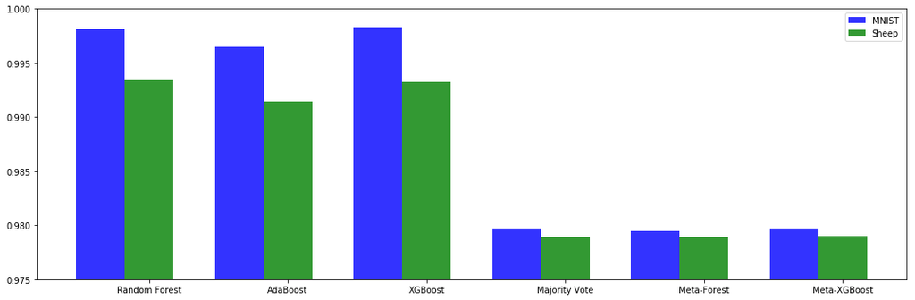

```python
barchart_double(0.975, 1.0, n_groups, list_mnist, 'MNIST', list_sheep, 'Sheep')
```

```python
mnist_precision = list(range(n_groups))
mnist_precision[0] = pr_mnist['Random Forest'][0]
mnist_precision[1] = pr_mnist['AdaBoost'][0]
mnist_precision[2] = pr_mnist['XGBoost'][0]
mnist_precision[3] = pr_mnist['Majority Vote'][0]
mnist_precision[4] = pr_mnist['Meta-Forest'][0]
mnist_precision[5] = pr_mnist['Meta-XGBoost'][0]

mnist_recall = list(range(n_groups))
mnist_recall[0] = pr_mnist['Random Forest'][1]
mnist_recall[1] = pr_mnist['AdaBoost'][1]
mnist_recall[2] = pr_mnist['XGBoost'][1]
mnist_recall[3] = pr_mnist['Majority Vote'][1]
mnist_recall[4] = pr_mnist['Meta-Forest'][1]
mnist_recall[5] = pr_mnist['Meta-XGBoost'][1]
```

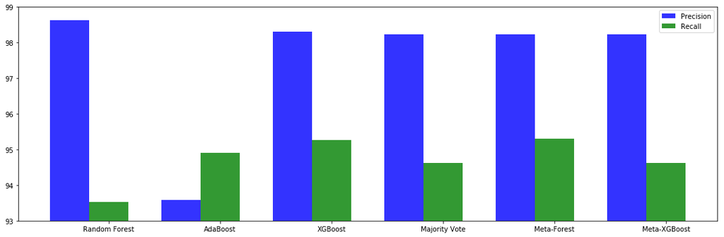

```python
barchart_double(93, 99, n_groups, mnist_precision, 'Precision', mnist_recall, 'Recall')
```

Figure 28: Bar chart of each model's precision and recall score on the heavily skewed MNIST dataset.  
Interestingly, AdaBoost performs better at recall (rate of correct True Positive detections) than precision (True Positive prediction accuracy). All other models perform better at precision, where Random Forest performs best but all perform roughly the same. The greater differences lie in each of the model's recall performance, where the XGBoost and Meta-Forest perform the best. These results show that in scenarios where either precision or recall performance is favoured rather than overall performance, model selection can differ. If the application's context requires that the model must maintain a high recall performance to sacrifice precision, AdaBoost or the slow XGBoost might warrant consideration over the Random Forest.